# 第11回 似た国を、くり返しでまとめる

k-meansをwhileで書く

# 導入

## 前回は、地図が左右に分かれた

① 場面●○○○○○

- 前回は、392台の車を主成分分析の地図に置いた
- アメリカ車と、日本・ヨーロッパ車が、左右に分かれて見えた

## 区切りは、どこに引く？

① 場面●●○○○○

- 地域の列が無かったら、どこで区切ればよいか
- 今日は、答えの列を使わずに、データをいくつかのグループに分ける

## 場面：国際協力機関の担当者

① 場面●●●○○○

- あなたは、国際協力機関の担当者
- 世界の国々に、保健や経済の支援をしている

## 似た国を、まとめたい

① 場面●●●●○○

- 142か国に1か国ずつ方針を立てるのは大変
- 状況の似た国をまとめて、グループごとに方針の土台を作りたい

## 答えの列は、どこにも無い

① 場面●●●●●○

- どの国がどのグループかを示す列は無い
- グループは、データから見つけるしかない
- 答えの列を使わずに分けることを、クラスタリング（clustering）と呼ぶ

## 決めたいこと

① 場面●●●●●●

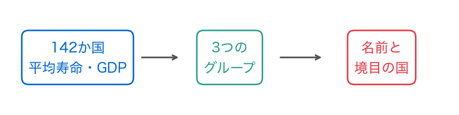

- 142か国を3つのグループに分け、名前を付け、境目の国を見つける

## 手元のデータ

② 手元のデータ●○○

- Gapminder財団が公開している、世界の国々の統計（plotly/datasets経由。CC-BY）
- 1行が、ある国のある年
- 1952年から2007年まで5年ごとに、平均寿命・人口・1人あたりGDPが並ぶ

## データをのぞく

② 手元のデータ●●○

```
       country continent  year  lifeExp       pop   gdpPercap iso_alpha  iso_num
0  Afghanistan      Asia  1952   28.801   8425333  779.445314       AFG        4
1  Afghanistan      Asia  1957   30.332   9240934  820.853030       AFG        4
2  Afghanistan      Asia  1962   31.997  10267083  853.100710       AFG        4
(1704, 8)
```

- アフガニスタンの1952年、1957年、1962年…と続く

## 今日使うのは2007年

② 手元のデータ●●●

- いちばん新しい2007年の142か国を使う
- 分けるのに使う列は、平均寿命と1人あたりGDPの2つ

## 最後に出す答え

③ 今日の問い●○

- 142か国を分けた3つのグループと、それぞれの名前
- どのグループとも言いにくい、境目にいる国

## 今日の問い

③ 今日の問い●●

答えの列が無い142か国を、どうやって3つのグループに分けるか？ 分けたグループは何を表すか？

## もう1つのねらい：くり返し

④ もう1つのねらい●○

- 止まる条件を書いて、`while`で「収束するまで」くり返せるようになる

## 何回くり返すかは、分からない

④ もう1つのねらい●●

- 今日の方法は、同じ手順を、答えが動かなくなるまでくり返す
- 何回で止まるかは、前もって分からない
- `for`ではなく、止まる条件を書く`while`を使う

## 今日の道筋

⑤ 今日の問い●

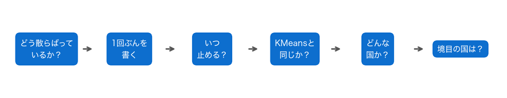

- 6つの小さな問いに答えていく

# 0. 準備

## まずは道具

- 第11回のノートを開き、上から順にセルを実行する
- 道具を呼び出し、データの置き場所を決める

## お手本：道具を呼び出す

0節 ① 道具●○

```python
import numpy as np
import pandas as pd
import matplotlib.pyplot as plt
from sklearn.preprocessing import StandardScaler
from sklearn.cluster import KMeans
```

- 標準化の`StandardScaler`と、答え合わせに使う`KMeans`

## データの置き場所

0節 ① 道具●●

```python
# データはこのリポジトリから読み込む
DATA_DIR = ('https://raw.githubusercontent.com/k0heiun0/'
            'applied_exercise_preview/main/shared/data')
```

- Gapminderのファイルは、この置き場所にある

## やってみよう：0節

0節 ② 確かめる●

- 0節のセルを上から実行する

動画の人は、ここで一時停止。

# 1. 142か国は、どう散らばっているか？

## 分ける前に、散らばりを見る

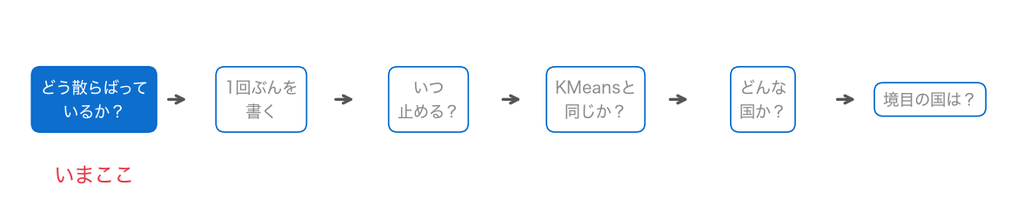

- 準備ができた。まず、142か国がどう散らばっているかを見る

## お手本：2007年を取り出す

1節 ① 取り出す●○○○

```python
gm = pd.read_csv(f'{DATA_DIR}/gapminder.csv')
d = gm[gm['year'] == 2007].reset_index(drop=True)
d = d.rename(columns={'country': '国', 'continent': '大陸',
                      'lifeExp': '平均寿命', 'gdpPercap': 'GDP'})
print(d.shape)
d[['国', '大陸', '平均寿命', 'GDP']].head(3).round(1)
```

## 1行ずつ読む

1節 ① 取り出す●●○○

- `gm['year'] == 2007`：2007年の行だけを選ぶ（真偽値で行を選ぶ。第1回）
- `reset_index(drop=True)`：行番号を0から振り直す
- `rename`：列の名前を、辞書`{'元の名前': '新しい名前'}`で付け替える

## 142か国

1節 ① 取り出す●●●○

```
(142, 14)
             国      大陸  平均寿命     GDP
0  Afghanistan    Asia  43.8   974.6
1      Albania  Europe  76.4  5937.0
2      Algeria  Africa  72.3  6223.4
```

- 1行が1か国になった。`GDP`は1人あたりGDP（ドル）

## 変えてみる：大陸ごとの数

1節 ① 取り出す●●●●

```python
d['大陸'].value_counts()
```

```
大陸
Africa      52
Asia        33
Europe      30
Americas    25
Oceania      2
```

- アフリカ52、アジア33、ヨーロッパ30、アメリカ大陸25、オセアニア2

## お手本：散布図で見る

1節 ② 散布図●○○

```python
plt.scatter(d['GDP'], d['平均寿命'], s=15)
plt.xlabel('1人あたりGDP（ドル）')
plt.ylabel('平均寿命（年）')
plt.show()
```

- 横に1人あたりGDP、縦に平均寿命をとって、142か国を点で描く

## 左の端が、詰まっていない？

1節 ② 散布図●●○

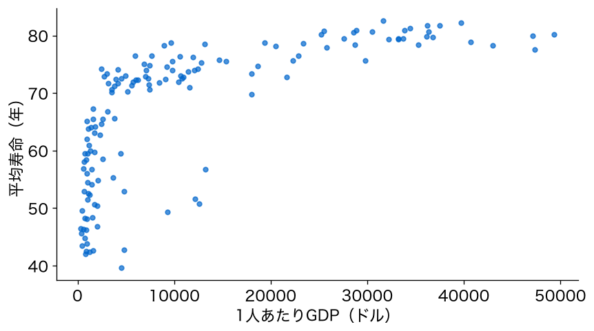

## 右に長く裾を引く

1節 ② 散布図●●●

```
min      278.0
50%     6124.0
max    49357.0
```

- 最小は278ドル、中央値は6124ドル、最大は49357ドル
- 少しの豊かな国が、右にまばらに伸びる
- このままでは、左の端の国どうしの違いが見えない

## 変えてみる：GDPを対数にする

1節 ③ 対数●○○○

```python
d['対数GDP'] = np.log10(d['GDP'])
plt.scatter(d['対数GDP'], d['平均寿命'], s=15)
plt.xlabel('対数GDP')
plt.ylabel('平均寿命（年）')
plt.show()
```

- `np.log10`は、10を底とする対数（常用対数）

## 対数の目盛り

1節 ③ 対数●●○○

```python
print(np.log10([1000, 10000]))
print(10 ** 3, 10 ** 4)
```

```
[3. 4.]
1000 10000
```

- 対数GDPが3なら1000ドル、4なら10000ドル
- 何倍違うかが、同じ幅で表される

## 帯のように並ぶ

1節 ③ 対数●●●○

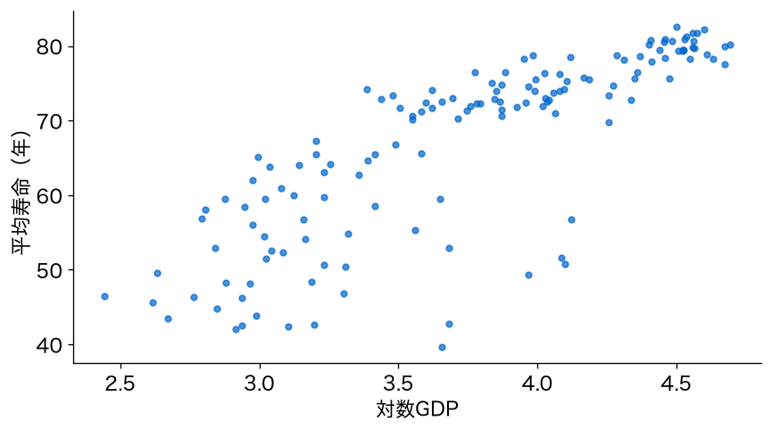

- 豊かな国ほど、平均寿命が長い

## 濃いところが、ありそう

1節 ③ 対数●●●●

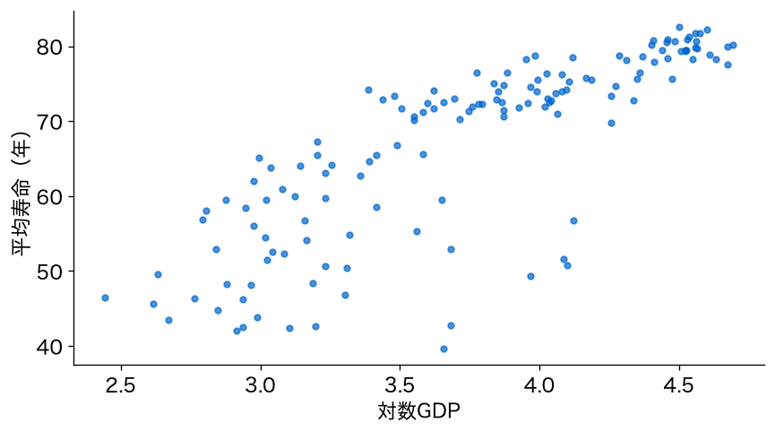

- 帯の中の濃いまとまりを、グループとして取り出したい

## 「似ている」を何で測る？

1節 ④ 物差し●○○

- 似ている国 ＝ 平面の上で近い国
- 国と国の近さは、距離で測る
- ところが、2つの列は、数の大きさがまったく違う

## お手本：標準偏差を見る

1節 ④ 物差し●●○

```python
d[['平均寿命', '対数GDP']].std().round(2)
```

```
平均寿命     12.07
対数GDP     0.59
```

- 平均寿命の標準偏差は12.07、対数GDPは0.59

## 日本と中国の差

1節 ④ 物差し●●●

```
        国   平均寿命  対数GDP
66  Japan  82.60    4.5
24  China  72.96    3.7
差の二乗: 93.0 0.65
```

- 差の二乗は、平均寿命が93、対数GDPが0.65
- このまま距離を測ると、平均寿命の違いばかりが効く

## おさらい：標準化

1節 ⑤ 標準化●○○○○

- 各列から平均を引き、標準偏差で割る（第4回・第7回）
- どの列も平均0、標準偏差1になり、物差しがそろう
- 前回の主成分分析と同じ理由で、距離の前にも標準化する

## お手本：標準化する

1節 ⑤ 標準化●●○○○

```python
sc = StandardScaler()
X = sc.fit_transform(d[['平均寿命', '対数GDP']])
print(X.shape)
print(X.mean(axis=0).round(2))
print(X.std(axis=0).round(2))
```

- `fit_transform`：平均と標準偏差を覚えて（fit）、変換する（transform）
- `sc`は、あとで使うので残しておく

## 平均0、標準偏差1

1節 ⑤ 標準化●●●○○

```
(142, 2)
[0. 0.]
[1. 1.]
```

- `X`は142行2列。どちらの列も平均0、標準偏差1

## 日本と中国の差、ふたたび

1節 ⑤ 標準化●●●●○

```
標準化した差の二乗: [0.64 1.88]
```

- 標準化すると、平均寿命が0.64、対数GDPが1.88
- 2つの列が、同じ物差しで効くようになった

## 標準化した142か国

1節 ⑤ 標準化●●●●●

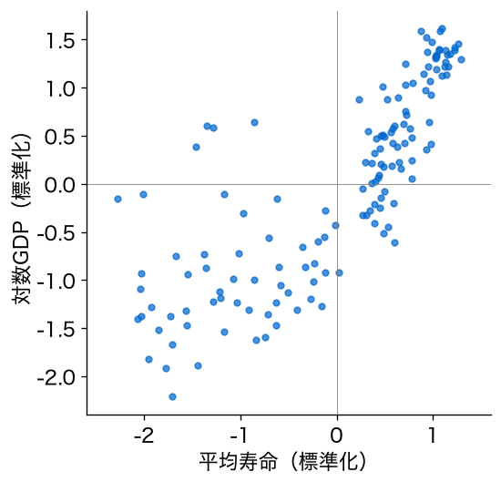

- 横が平均寿命、縦が対数GDP。ここからは、この平面で分ける

## やってみよう：1節

1節 ⑥ 確かめる●○

- 1節のお手本を上から実行する
- 対数にする前と後の散布図、標準化した`X`を確かめる

動画の人は、ここで一時停止。

## 確かめる：142行2列

1節 ⑥ 確かめる●●

- 2007年の142か国を取り出し、GDPを対数にした
- 2列を標準化した`X`は142行2列
- この`X`を、3つのグループに分ける

# 2. 1回ぶんの手順は、どう書くか？

## どうやって3つに分ける？

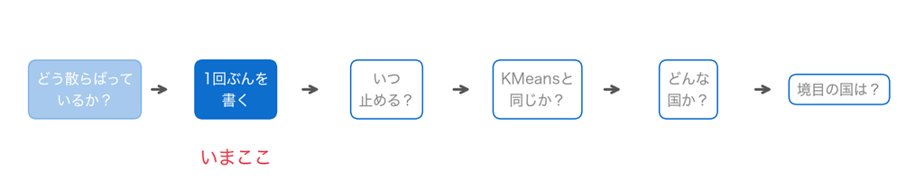

- 物差しがそろった。手順を式で書き、1回ぶんをコードに写す

## 名前：k-means

2節 ① 考え方●○○○

- グループの数$K$を先に決め、各グループに1つずつ中心を置いて分ける方法
- k-means（ケイ・ミーンズ）と呼ぶ。今日は$K=3$
- グループのことを、クラスター（cluster）とも呼ぶ

## 2つの手順

2節 ① 考え方●●○○

- 割り当て：各国を、いちばん近い中心のグループに入れる
- 更新：各グループの中心を、そのグループの国の重心（平均）に動かす

## 出発点は、人が決める

2節 ① 考え方●●●○

- 最初の中心（出発点）は、人が決める
- 今日は、日本・インド・ナイジェリアの3か国を出発点にする

## 3つの出発点

2節 ① 考え方●●●●

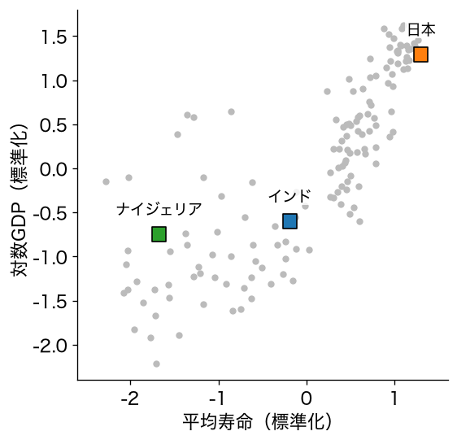

- ■が中心。まだどの国も、どのグループにも入っていない

## 記号を決める

2節 ② 式●○○○○

- 国$i$の標準化した値：$\mathbf x_i = (x_{i1}, x_{i2})$（平均寿命, 対数GDP）
- グループ$k$の中心：$\mathbf c_k = (c_{k1}, c_{k2})$
- $i$は1から142まで、$k$は0・1・2

## 割り当ての式

2節 ② 式●●○○○

国$i$と中心$k$の距離の二乗

$$d_{ik} = \|\mathbf x_i - \mathbf c_k\|^2 = (x_{i1} - c_{k1})^2 + (x_{i2} - c_{k2})^2$$

- 国$i$は、$d_{ik}$がいちばん小さい$k$のグループに入る

## 1か国で計算する

2節 ② 式●●●○○

```
アフガニスタン: [-1.93 -1.28]
中心0（インド）: [-0.19 -0.6 ]
差の二乗: [3.01 0.47]
距離の二乗: 3.48
```

- $(-1.93 - (-0.19))^2 + (-1.28 - (-0.6))^2 = 3.01 + 0.47 = 3.48$

## 3つの中心までの距離

2節 ② 式●●●●○

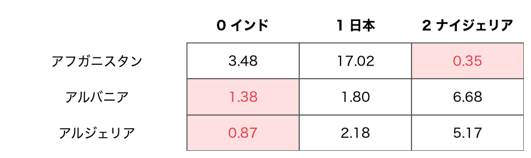

- 行ごとに、いちばん小さい列（赤）が、その国の入るグループ

## 更新の式

2節 ② 式●●●●●

グループ$k$に入った国の集まりを$G_k$、その国の数を$n_k$とすると

$$\mathbf c_k = \frac{1}{n_k} \sum_{i \in G_k} \mathbf x_i$$

- 新しい中心は、グループに入った国の平均（重心）

## お手本：出発点を決める

2節 ③ 出発点●○

```python
start = d.index[d['国'].isin(['Japan', 'India', 'Nigeria'])]
print(list(start))
C = X[start]
C.round(2)
```

- `d.index[...]`：条件に合う行の行番号を取り出す
- `X[start]`：その行番号の行を、`X`から取り出す

## 3か国の中心

2節 ③ 出発点●●

```
[58, 66, 94]
[[-0.19 -0.6 ]
 [ 1.3   1.29]
 [-1.67 -0.75]]
```

- `isin`で選ぶと、表の並び（国名のアルファベット順）になる
- 中心0がインド、中心1が日本、中心2がナイジェリア

## お手本：距離の表を作る

2節 ④ 距離の表●○○○

```python
D = np.zeros((len(X), 3))
for k in range(3):
    D[:, k] = ((X - C[k]) ** 2).sum(axis=1)
print(D.shape)
D[:3].round(2)
```

## 1行ずつ読む

2節 ④ 距離の表●●○○

- `np.zeros((142, 3))`：0の並んだ142行3列の表を作る
- `for k in range(3)`：中心ごとに、1列ずつ埋める
- `D[:, k] = ...`：表の`k`列目に、142か国ぶんの値を入れる

## X - C[k]

2節 ④ 距離の表●●●○

- `X`は142行2列、`C[k]`は2つの値
- `X - C[k]`は、142か国それぞれから中心`k`を引く
- `** 2`で二乗し、`sum(axis=1)`で横（2つの列）に足す（第9回）

## 142行3列の表

2節 ④ 距離の表●●●●

```
(142, 3)
[[ 3.48 17.02  0.35]
 [ 1.38  1.8   6.68]
 [ 0.87  2.18  5.17]]
```

- 1行目のアフガニスタンは、中心2（ナイジェリア）まで0.35がいちばん小さい
- 図の表と同じ数

## お手本：いちばん近い中心を選ぶ

2節 ⑤ 割り当て●○○○

```python
lab = D.argmin(axis=1)
print(lab[:5])
print(np.bincount(lab))
```

- `argmin(axis=1)`：行ごとに、いちばん小さい値がある列の番号
- `np.bincount`：0・1・2が、それぞれ何個あるかを数える

## 1回目の割り当て

2節 ⑤ 割り当て●●○○

```
[2 0 0 2 1]
[51 57 34]
```

- アフガニスタンはグループ2、アルバニアとアルジェリアはグループ0
- グループの国の数は、51・57・34

## 色で見る

2節 ⑤ 割り当て●●●○

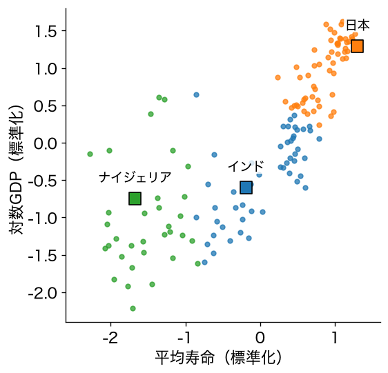

- 各国が、いちばん近い■の色に塗られた

## 境目は、中心と中心の真ん中

2節 ⑤ 割り当て●●●●

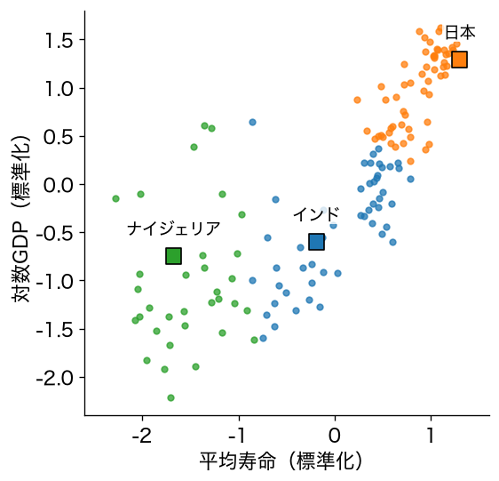

- 2つの中心から同じ距離の線が、色の境目になる
- いまの境目は、出発点の3か国の位置で決まっている

## お手本：中心を重心に動かす

2節 ⑥ 更新●○○○

```python
C_new = np.zeros((3, 2))
for k in range(3):
    C_new[k] = X[lab == k].mean(axis=0)
C_new.round(2)
```

- `X[lab == k]`：グループ`k`に入った国の行だけを取り出す（真偽値で行を選ぶ）
- `mean(axis=0)`：列ごとの平均。グループの重心

## 新しい中心

2節 ⑥ 更新●●○○

```
[[ 0.05 -0.43]
 [ 0.87  0.99]
 [-1.52 -1.02]]
```

- 3つの中心が、どれも動いた

## 中心が動く

2節 ⑥ 更新●●●○

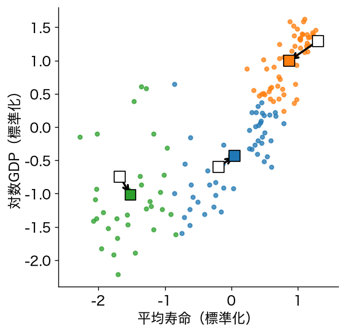

- 白い■が元の中心、色の■が新しい中心

## 日本の中心が、大きく動いた

2節 ⑥ 更新●●●●

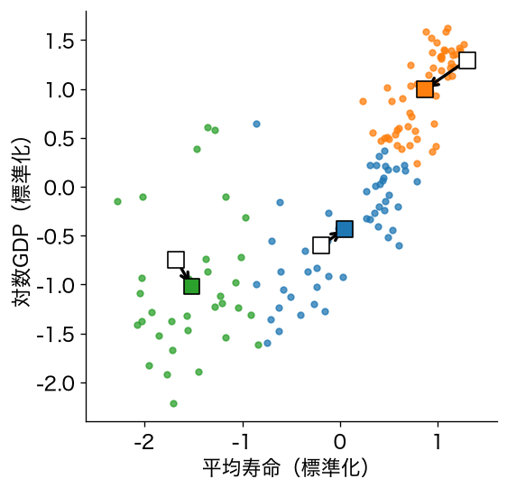

- 日本という1か国の位置から、同じグループの国々の真ん中へ

## TODO①：2回目

2節 ⑦ 2回目●○○○○○

```python
# TODO: 中心を入れ替えて、2回目の割り当てと更新をする
# ヒント: C = C_new
#         D を作り直す → lab = D.argmin(axis=1)
#         → C_new を作り直す
#         print(np.bincount(lab))
#         print(np.abs(C_new - C).max().round(3))
...
```

- グループの国の数と、中心がどれだけ動いたかを表示する

## やってみよう：2節とTODO①

2節 ⑦ 2回目●●○○○○

- 2節のお手本を上から実行する
- TODO①で、中心を入れ替えて2回目をする

動画の人は、ここで一時停止。

## 答え合わせ：TODO①

2節 ⑦ 2回目●●●○○○

```python
C = C_new
D = np.zeros((len(X), 3))
for k in range(3):
    D[:, k] = ((X - C[k]) ** 2).sum(axis=1)
lab = D.argmin(axis=1)
C_new = np.zeros((3, 2))
for k in range(3):
    C_new[k] = X[lab == k].mean(axis=0)
print(np.bincount(lab))
print(np.abs(C_new - C).max().round(3))
```

## 42・61・39

2節 ⑦ 2回目●●●●○○

```
[42 61 39]
0.103
```

- 2回目の割り当ては、42・61・39か国
- 中心のずれの最大は0.103

## 2回目の動き

2節 ⑦ 2回目●●●●●○

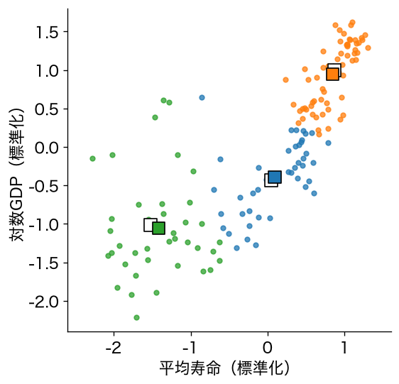

- 1回目より、動きが小さくなった

## まだ0ではない

2節 ⑦ 2回目●●●●●●

- 中心が動いたので、3回目をすれば、割り当てがまた変わるかもしれない
- 何回くり返せばよいのか？

# 3. いつ止めればよいか？

## 何回くり返せばよい？

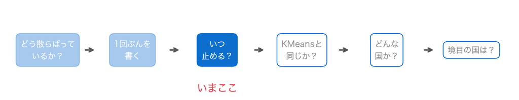

- 1回ぶんの手順が書けた。けれども、何回くり返せばよいかは、前もって分からない

## 回数ではなく、条件で止める

3節 ① while●○○○○○

- 「中心が動かなくなるまで」くり返したい
- 回数を決めずに、止まる条件を書く

## おさらい：for

3節 ① while●●○○○○

```python
for k in range(3):
    print(k)
```

```
0
1
2
```

- `for`は、決まった回数（並びの要素の数）だけくり返す

## while：条件のあいだ、くり返す

3節 ① while●●●○○○

```python
n = 0
while n < 3:
    print(n)
    n = n + 1
```

- `while 条件:`は、条件が`True`のあいだ、字下げしたかたまりをくり返す
- 条件が`False`になったら、くり返しを抜ける

## 0・1・2で止まる

3節 ① while●●●●○○

```
0
1
2
```

- `n`が3になると`n < 3`が`False`になり、抜ける

## 1回ずつ追う

3節 ① while●●●●●○

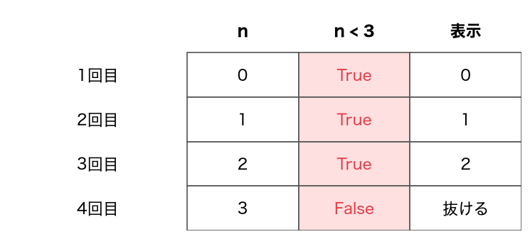

- 条件を確かめてから、かたまりに入る

## 止まる条件を、中で変える

3節 ① while●●●●●●

- かたまりの中で`n = n + 1`と書き換えるから、いつか止まる
- 書き換えを忘れると、いつまでも止まらない
- `for`と違い、止まるかどうかは自分で書く

## 「動かなくなった」をどう書く？

3節 ② allclose●○○○

- 新しい中心と古い中心が、同じかどうか
- けれども、小数の計算には、ごくわずかな誤差が入る

## お手本：np.allclose

3節 ② allclose●●○○

```python
print(0.1 + 0.2 == 0.3)
print(np.allclose(0.1 + 0.2, 0.3))
print(np.allclose([1.0, 2.0], [1.0, 2.1]))
```

```
False
True
False
```

## ==では、ずれる

3節 ② allclose●●●○

- `0.1 + 0.2`は、コンピュータの中ではわずかに0.3からずれる
- `np.allclose`は、ごくわずかな違いは同じとみなす
- 0.1も違えば、`False`

## not：入れ替える

3節 ② allclose●●●●

- `not`を前に付けると、`True`と`False`が入れ替わる
- 「動いた」は`not np.allclose(C_new, C)`

## くり返しのたびに、よくなる？

3節 ③ 慣性●○○○

- くり返しで、分け方がよくなっているかを測りたい
- 各国が、自分の中心の近くにまとまっているほど、よい分け方

## 名前：慣性

3節 ③ 慣性●●○○

$$J = \sum_{i=1}^{142} \min_k d_{ik}$$

- 各国から、自分のグループの中心までの距離の二乗を、142か国ぶん足したもの
- 慣性（inertia）と呼ぶ。小さいほど、中心の近くにまとまっている

## 線の長さの二乗の和

3節 ③ 慣性●●●○

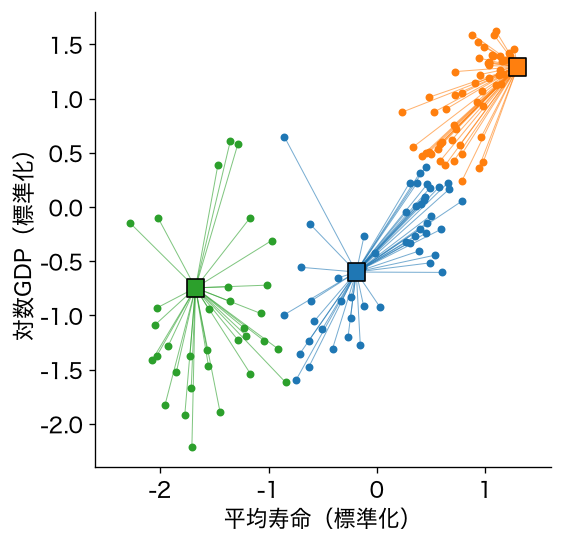

- 各国から自分の■までの線。慣性は、この線の長さの二乗の和

## コードでは1行

3節 ③ 慣性●●●●

```python
D.min(axis=1).sum()
```

- `D.min(axis=1)`：行ごとに、いちばん小さい距離の二乗
- `.sum()`：142か国ぶん足す

## お手本：動かなくなるまで

3節 ④ くり返す●○○○○○○

```python
C = X[start]
n = 0
moved = True
while moved:
    D = np.zeros((len(X), 3))
    for k in range(3):
        D[:, k] = ((X - C[k]) ** 2).sum(axis=1)
    lab = D.argmin(axis=1)
    C_new = np.zeros((3, 2))
    for k in range(3):
        C_new[k] = X[lab == k].mean(axis=0)
    moved = not np.allclose(C_new, C)
    C = C_new
    n = n + 1
    print(n, D.min(axis=1).sum().round(2))
```

## かたまりで読む

3節 ④ くり返す●●○○○○○

- `D`を作り、`lab`を選び、`C_new`を作る：2節のセルそのまま
- `moved = ...`：中心が動いたかを書き換える
- `C = C_new`と`n = n + 1`：次の回の準備。最後に回数と慣性を表示

## moved = Trueから始める

3節 ④ くり返す●●●○○○○

- 1回目は、まだ何も計算していない
- `moved = True`から始めるので、1回目は必ずかたまりに入る
- 動かなくなると`moved`が`False`になり、抜ける

## 5回で止まった

3節 ④ くり返す●●●●○○○

```
1 84.85
2 57.98
3 56.9
4 55.56
5 55.4
```

- 慣性は、84.85、57.98、56.9、55.56、55.4

## 回るたびに下がる

3節 ④ くり返す●●●●●○○

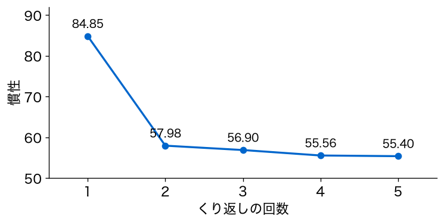

- 1回目から2回目で大きく下がり、そのあとは少しずつ

## 中心の動き

3節 ④ くり返す●●●●●●○

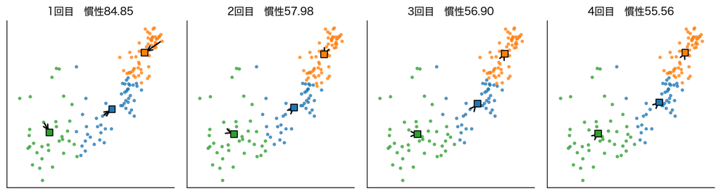

- 回るたびに、中心の動きが小さくなる

## 割り当てが変わった国の数

3節 ④ くり返す●●●●●●●

```
1回目 → 2回目: 9 か国
2回目 → 3回目: 6 か国
3回目 → 4回目: 3 か国
4回目 → 5回目: 0 か国
```

- 9か国、6か国、3か国と減り、5回目で0か国
- 割り当てが変わらないので、中心も動かない

## なぜ、必ず止まる？

3節 ⑤ 止まる理由●○○○

- 慣性は、2つの手順のどちらでも、増えることがない
- 1つずつ確かめる

## 割り当てでは、増えない

3節 ⑤ 止まる理由●●○○

- 各国を、いちばん近い中心に入れ直す
- どの国も、距離の二乗は前より大きくならない

## 更新でも、増えない

3節 ⑤ 止まる理由●●●○

- グループの中で、距離の二乗の和をいちばん小さくする点は、重心（平均）
- 中心を重心に動かしても、慣性は大きくならない

## 分け方の数は、有限

3節 ⑤ 止まる理由●●●●

- 142か国を3つに分ける分け方は、数は多いが有限
- 慣性が下がり続けるかぎり、同じ分け方には戻れない
- いつかは割り当てが変わらなくなり、中心も動かなくなる

## TODO②：回数の上限

3節 ⑥ 上限●○○○○○

```python
# TODO: while の条件に回数の上限を足し、3回で打ち切る
# ヒント: while moved and n < 3:
#         （上のお手本のセルを写して、この1行だけ変える）
...
```

- `and`：2つの条件の両方が`True`のときだけ`True`

## なぜ上限を付ける？

3節 ⑥ 上限●●○○○○

- 止まる理由はあっても、計算の誤差などで、いつまでも止まらないことがある
- 上限を付けておくと、どこかで必ず抜ける

## やってみよう：3節とTODO②

3節 ⑥ 上限●●●○○○

- 3節のお手本を上から実行する
- TODO②で、回数の上限を付けて、3回で打ち切る

動画の人は、ここで一時停止。

## 答え合わせ：TODO②

3節 ⑥ 上限●●●●○○

```python
C = X[start]
n = 0
moved = True
while moved and n < 3:
    D = np.zeros((len(X), 3))
    for k in range(3):
        D[:, k] = ((X - C[k]) ** 2).sum(axis=1)
    lab = D.argmin(axis=1)
    C_new = np.zeros((3, 2))
    for k in range(3):
        C_new[k] = X[lab == k].mean(axis=0)
    moved = not np.allclose(C_new, C)
    C = C_new
    n = n + 1
    print(n, D.min(axis=1).sum().round(2))
print(moved)
```

## 3回で打ち切られた

3節 ⑥ 上限●●●●●○

```
1 84.85
2 57.98
3 56.9
True
```

- 慣性が56.9のところで打ち切られた
- 中心はまだ動いていたので、`moved`は`True`のまま

## 上限は大きく

3節 ⑥ 上限●●●●●●

- ふだんは、上限を100のように大きくしておく
- 上限で止まったら（`moved`が`True`のまま）、収束していないと気づける

# 4. KMeansと同じ答えになるか？

## 答えを確かめたい

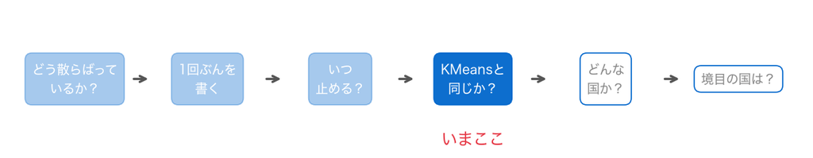

- 自分で書いたk-meansが、5回で止まった。この答えは確かか

## 確かめたいことは2つ

4節 ① 関数●○○○○

- scikit-learnの`KMeans`と、同じ答えになるか
- 別の出発点から始めたら、同じ答えになるか
- どちらも、3節のくり返しを、もう一度書くことになる

## 2回目は、関数にまとめる

4節 ① 関数●●○○○

- 同じことを2回目にしたくなったら、`def`でまとめる
- 出発点だけを変えて、何度でも呼べるようにする

## お手本：my_kmeans

4節 ① 関数●●●○○

```python
def my_kmeans(X, C):
    """中心が動かなくなるまで、割り当てと更新をくり返す"""
    moved = True
    while moved:
        D = np.zeros((len(X), len(C)))
        for k in range(len(C)):
            D[:, k] = ((X - C[k]) ** 2).sum(axis=1)
        lab = D.argmin(axis=1)
        C_new = np.zeros(C.shape)
        for k in range(len(C)):
            C_new[k] = X[lab == k].mean(axis=0)
        moved = not np.allclose(C_new, C)
        C = C_new
    J = D.min(axis=1).sum()
    return lab, C, J
```

## 役割・入力・出力

4節 ① 関数●●●●○

- 役割：中心が動かなくなるまで、割り当てと更新をくり返す（docstring）
- 入力：標準化した値`X`と、出発点の中心`C`
- 出力：割り当て`lab`、最後の中心`C`、慣性`J`

## 3節のセルとの違い

4節 ① 関数●●●●●

- 表示の代わりに、`return`で3つの値を返す
- `3`を`len(C)`（中心の数）にした。中心の数を変えても使える
- 回数`n`の表示は、外した

## お手本：関数を呼ぶ

4節 ② 呼ぶ●○

```python
lab_a, C_a, J_a = my_kmeans(X, X[start])
print(np.bincount(lab_a), round(J_a, 2))
```

- 3つの返す値を、3つの名前で受け取る（前回の`pca, S`と同じ）

## 3節と同じ55.4

4節 ② 呼ぶ●●

```
[41 57 44] 55.4
```

- 日本・インド・ナイジェリアから始めると、慣性は55.4
- グループの国の数は、41・57・44

## お手本：KMeansで回す

4節 ③ KMeans●○○○

```python
km1 = KMeans(n_clusters=3, init=X[start], n_init=1).fit(X)
print((km1.labels_ == lab_a).all())
print(km1.n_iter_, round(km1.inertia_, 2))
```

- `init=`：出発点を渡す。`n_init=1`：その出発点から1回だけ回す
- `n_iter_`はくり返しの回数、`inertia_`は慣性

## 1行ずつ読む

4節 ③ KMeans●●○○

- `km1.labels_`：`KMeans`の割り当て（142か国ぶん）
- `km1.labels_ == lab_a`：1か国ずつ同じかの真偽値
- `.all()`：すべて`True`なら`True`

## 完全に一致

4節 ③ KMeans●●●○

```
True
5 55.4
```

- 142か国の割り当てが、すべて一致した
- くり返しも5回、慣性も55.4で同じ

## KMeansの中身

4節 ③ KMeans●●●●

- `KMeans`の中でも、今日書いた2つの手順がくり返されている

## 出発点を変えたら？

4節 ④ 出発点●○○○○○

- 出発点は、人が決めたものだった
- 別の出発点から始めたら、同じ答えになるか

## TODO③：先頭の3か国から

4節 ④ 出発点●●○○○○

```python
# TODO: 表の先頭の3か国を出発点にして my_kmeans を呼ぶ
# ヒント: lab_b, C_b, J_b = my_kmeans(X, X[:3])
...
```

- アフガニスタン・アルバニア・アルジェリアの`X[:3]`を出発点にする

## やってみよう：4節とTODO③

4節 ④ 出発点●●●○○○

- 4節のお手本を上から実行する
- TODO③で、表の先頭の3か国から始める

動画の人は、ここで一時停止。

## 答え合わせ：TODO③

4節 ④ 出発点●●●●○○

```python
lab_b, C_b, J_b = my_kmeans(X, X[:3])
print(np.bincount(lab_b), round(J_b, 2))
```

```
[46 47 49] 54.67
```

## 慣性は54.67

4節 ④ 出発点●●●●●○

- 先頭の3か国から始めると、慣性は54.67
- 日本・インド・ナイジェリアから始めたとき（55.4）と違う
- グループの国の数も、46・47・49と違う

## 別の分け方で止まった

4節 ④ 出発点●●●●●●

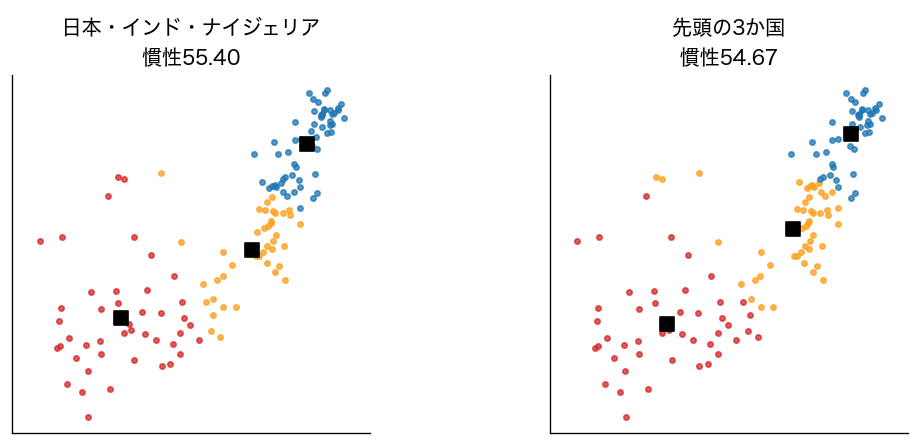

- 境目の位置が、左右で違う

## 止まる先は、出発点で変わる

4節 ⑤ 局所解●○

- k-meansは、慣性が下がらなくなったところで止まる
- そこが、慣性がいちばん小さい分け方とは限らない

## 名前：局所解

4節 ⑤ 局所解●●

- まわりの分け方より慣性は小さいが、いちばん小さいとは限らない答え
- 局所解（local optimum）と呼ぶ
- どの局所解で止まるかは、出発点で決まる

## 出発点をいくつも試す

4節 ⑥ n_init●○○○

- いくつかの出発点から回し、慣性がいちばん小さい答えを残せばよい
- `KMeans`は、`n_init`で、試す出発点の数を指定できる

## お手本：n_init=10

4節 ⑥ n_init●●○○

```python
km = KMeans(n_clusters=3, n_init=10, random_state=0).fit(X)
print(np.bincount(km.labels_), round(km.inertia_, 2))
```

- 出発点を変えて10回回し、慣性がいちばん小さい答えを残す
- `random_state=0`：出発点の選び方に使う乱数のシードを固定する

## 慣性は53.75

4節 ⑥ n_init●●●○

```
[52 51 39] 53.75
```

- 自分で試した2つの出発点（55.4と54.67）のどちらよりも小さい
- ここからは、この`km`の分け方を使う

## 3つの答えを並べる

4節 ⑥ n_init●●●●

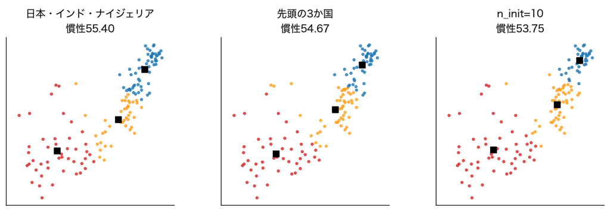

- 3つとも、左・真ん中・右に分けているが、境目の位置が違う

# 5. 3つのグループは、どんな国か？

## 番号には、意味がない

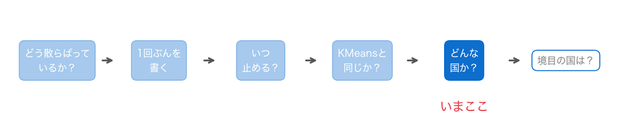

- 142か国が3つに分かれた。けれども、番号0・1・2には意味がない

## 番号は入れ替わる

5節 ① グループの列●○

- 出発点が変われば、同じグループでも番号が入れ替わる
- グループの中身を要約して、名前を付ける

## お手本：グループの列を足す

5節 ① グループの列●●

```python
d['グループ'] = km.labels_
d['グループ'].value_counts()
```

```
グループ
0    52
1    51
2    39
```

- `km`の割り当てを、表`d`の列`グループ`にした

## おさらい：groupbyとagg

5節 ② 要約●○○○○○

```python
d.groupby('大陸').agg(国数=('国', 'size'))
```

```
          国数
大陸
Africa    52
Americas  25
Asia      33
Europe    30
Oceania    2
```

- `新しい列名=('列', '計算')`の形で、いくつも並べられる

## TODO④：グループを要約する

5節 ② 要約●●○○○○

```python
# TODO: グループごとの国の数・平均寿命の平均・GDPの中央値
# ヒント: d.groupby('グループ').agg(国数=('国', 'size'),
#                                   平均寿命=('平均寿命', 'mean'),
#                                   GDP中央値=('GDP', 'median'))
...
```

- GDPは右に裾を引いていたので、中央値で要約する

## やってみよう：5節とTODO④

5節 ② 要約●●●○○○

- 5節のお手本を上から実行する
- TODO④で、3つのグループを要約する

動画の人は、ここで一時停止。

## 答え合わせ：TODO④

5節 ② 要約●●●●○○

```python
d.groupby('グループ').agg(国数=('国', 'size'),
                          平均寿命=('平均寿命', 'mean'),
                          GDP中央値=('GDP', 'median')).round(1)
```

```
      国数  平均寿命   GDP中央値
グループ
0     52  53.0   1209.3
1     51  72.2   7092.9
2     39  78.8  30470.0
```

## 段階的に上がる

5節 ② 要約●●●●●○

- 国の数は52・51・39
- 平均寿命の平均は53.0年・72.2年・78.8年
- GDPの中央値は1209.3ドル・7092.9ドル・30470ドル

## 2つの列が、そろって上がる

5節 ② 要約●●●●●●

- 平均寿命の短いグループほど、GDPも小さい
- 番号の順は、環境によって入れ替わることがある

## お手本：名前を付ける

5節 ③ 名前●○○○

```python
life = d.groupby('グループ')['平均寿命'].mean()
order = life.sort_values().index
name = {order[0]: '低寿命・低所得', order[1]: '中位',
        order[2]: '長寿・高所得'}
d['名前'] = d['グループ'].map(name)
d['名前'].value_counts()
```

## 1行ずつ読む

5節 ③ 名前●●○○

- `life.sort_values().index`：平均寿命の平均が短い順の、グループ番号
- `name`：グループ番号から名前への辞書
- `map(name)`：辞書で値を置き換える（前回の地域の名前と同じ）

## 番号が変わっても、名前は同じ

5節 ③ 名前●●●○

```
名前
低寿命・低所得    52
中位         51
長寿・高所得     39
```

- 平均寿命の順で名前を付けたので、番号が入れ替わっても同じグループに付く

## 3つのグループ

5節 ③ 名前●●●●

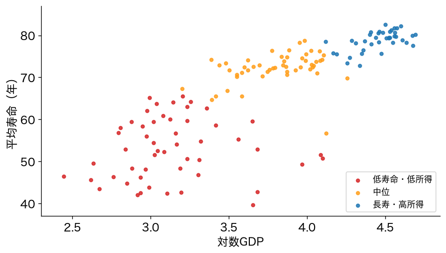

- 元の目盛り（対数GDPと平均寿命）に戻して描いた

## グループと大陸は？

5節 ④ 大陸●○○○○○

- 大陸の列は、分けるのに使っていない
- グループは、大陸とどれくらい重なるか

## お手本：グループと大陸

5節 ④ 大陸●●○○○○

```python
pd.crosstab(d['名前'], d['大陸'])
```

- `pd.crosstab`：2つの区分の組み合わせごとに、数を数えた表（第6回）

## クロス集計表

5節 ④ 大陸●●●○○○

```
大陸       Africa  Americas  Asia  Europe  Oceania
名前
中位            8        20    16       7        0
低寿命・低所得      44         1     7       0        0
長寿・高所得        0         4    10      23        2
```

## アフリカとヨーロッパ

5節 ④ 大陸●●●●○○

- 低寿命・低所得の52か国のうち、44か国がアフリカ
- 長寿・高所得の39か国のうち、23か国がヨーロッパ

## 中位は、いろいろな大陸

5節 ④ 大陸●●●●●○

- 中位の51か国は、アメリカ大陸20、アジア16、アフリカ8、ヨーロッパ7
- アジアは、3つのグループすべてに入っている

## 大陸を知らずに、似た国を集めた

5節 ④ 大陸●●●●●●

- グループは大陸とかなり重なるが、同じではない
- 平均寿命と豊かさだけから、似た国を集めた

# 6. どの国が、境目にいるか？

## どの国も典型的？

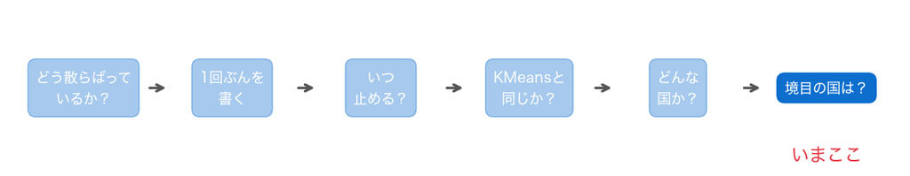

- 3つのグループに名前が付いた。けれども、どの国も同じように典型的とは限らない

## お手本：気になる国

6節 ① 気になる国●○○○

```python
pick = ['Japan', 'China', 'India', 'Botswana', 'Equatorial Guinea']
d.loc[d['国'].isin(pick), ['国', '名前', '平均寿命', 'GDP']].round(1)
```

```
                    国       名前  平均寿命      GDP
13           Botswana  低寿命・低所得  50.7  12569.9
24              China       中位  73.0   4959.1
40  Equatorial Guinea  低寿命・低所得  51.6  12154.1
58              India       中位  64.7   2452.2
66              Japan   長寿・高所得  82.6  31656.1
```

## 豊かなのに、低寿命・低所得？

6節 ① 気になる国●●○○

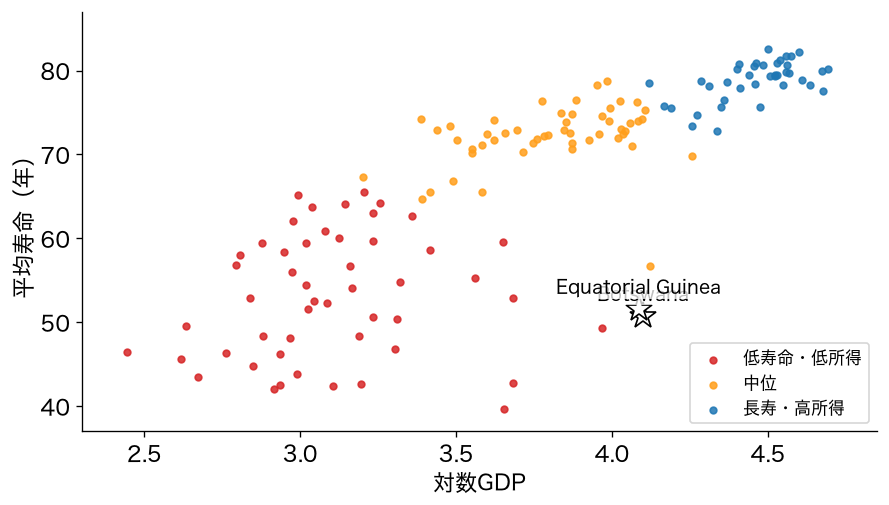

## 寿命の短さで、入った

6節 ① 気になる国●●●○

- ボツワナと赤道ギニアは、GDPが12569.9ドルと12154.1ドルで、中位の多くの国より豊か
- けれども、平均寿命は50.7年と51.6年で短い
- 2つの列で測ったので、低寿命・低所得のグループに入った

## GDPだけなら、見落とす

6節 ① 気になる国●●●●

- GDPだけを見ていたら、豊かな国に見える
- 支援の方針も、所得より保健を中心に考える必要がありそう

## 境目にいる国は？

6節 ② 中心までの距離●○○○○

- グループの境目の近くにいる国は、わずかな違いで別のグループに入る
- 中心までの距離で、境目の国を探す

## 名前：km.transform

6節 ② 中心までの距離●●○○○

- `km.transform(X)`は、各国から3つの中心までの距離を、142行3列で返す
- 二乗しない、ふつうの距離

## 1か国から3つの中心まで

6節 ② 中心までの距離●●●○○

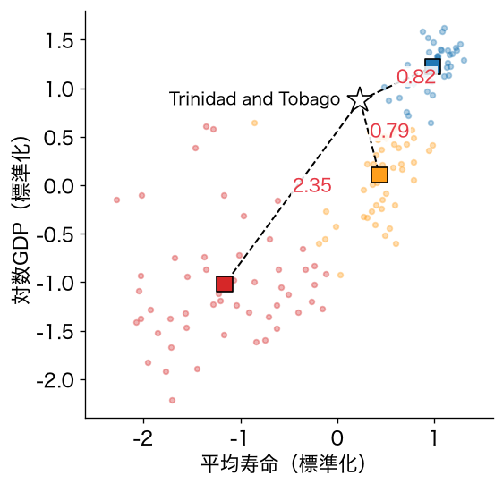

- 近い2つの中心まで、ほぼ同じ距離

## お手本：距離の差

6節 ② 中心までの距離●●●●○

```python
dist = np.sort(km.transform(X), axis=1)
d['差'] = dist[:, 1] - dist[:, 0]
dist[:3].round(2)
```

- `np.sort(..., axis=1)`：行ごとに、小さい順に並べ替える
- 1列目がいちばん近い中心まで、2列目が2番目に近い中心まで

## 並べ替えた距離

6節 ② 中心までの距離●●●●●

```
[[0.81 2.74 3.84]
 [0.35 1.18 2.22]
 [0.02 1.26 1.95]]
```

- 差（2列目 − 1列目）が小さい国ほど、2つの中心からほぼ同じ距離にいる
- 差が小さい国が、境目の国

## TODO⑤：境目の国

6節 ③ 境目●○○○○○

```python
# TODO: 差の小さい順に5か国を表示する
# ヒント: cols = ['国', '名前', '平均寿命', 'GDP', '差']
#         d.sort_values('差')[cols].head(5).round(3)
...
```

- 境目にいる5か国の、国名・名前・平均寿命・GDP・差を表示する

## やってみよう：6節とTODO⑤

6節 ③ 境目●●○○○○

- 6節のお手本を上から実行する
- TODO⑤で、境目にいる5か国を探す

動画の人は、ここで一時停止。

## 答え合わせ：TODO⑤

6節 ③ 境目●●●○○○

```python
cols = ['国', '名前', '平均寿命', 'GDP', '差']
d.sort_values('差')[cols].head(5).round(3)
```

```
                       国       名前    平均寿命        GDP      差
129  Trinidad and Tobago       中位  69.819  18008.509  0.030
61                  Iraq  低寿命・低所得  59.545   4471.062  0.065
69      Korea, Dem. Rep.       中位  67.297   1593.065  0.086
4              Argentina       中位  75.320  12779.380  0.091
82                Mexico       中位  76.195  11977.575  0.111
```

## 境目の5か国

6節 ③ 境目●●●●○○

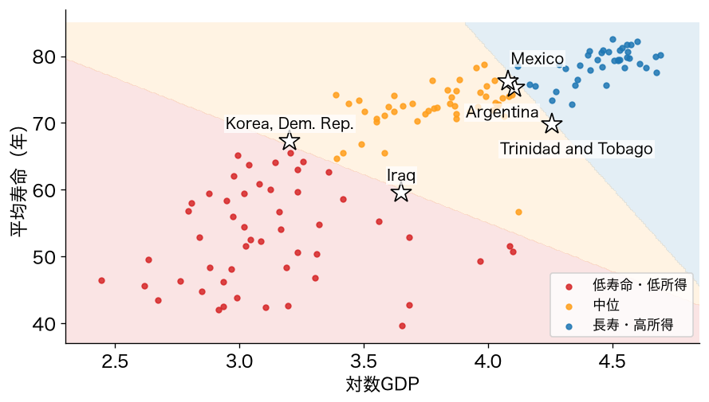

- 薄い色が、各グループの受け持ちの範囲。★が境目の国

## トリニダード・トバゴ

6節 ③ 境目●●●●●○

- 差は0.03で、いちばん境目にいる
- 中位と長寿・高所得の境目にいる
- わずかな違いで、グループが入れ替わってもおかしくない

## 必ずどこかに入れる

6節 ③ 境目●●●●●●

- k-meansは、どの国も必ずどこか1つのグループに入れる
- 境目の国は、グループの方針をそのまま当てはめず、1か国ずつ確かめる

## 答え：3つのグループ

6節 ④ 答え●○○

- 低寿命・低所得（52か国）：平均寿命53.0年、GDPの中央値1209.3ドル
- 中位（51か国）：72.2年、7092.9ドル
- 長寿・高所得（39か国）：78.8年、30470ドル

## 答え：分け方

6節 ④ 答え●●○

- 平均寿命と対数GDPを標準化し、k-meansで3つに分けた
- 割り当てと更新を、中心が動かなくなるまでくり返す
- 止まる先は出発点で変わるので、出発点を何通りも試し、慣性のいちばん小さい答えを残した

## 答え：1か国ずつ見る国

6節 ④ 答え●●●

- ボツワナや赤道ギニア：GDPは高いが、寿命が短い
- トリニダード・トバゴ：グループの境目にいる
- どちらも、グループの方針をそのまま当てはめない

## まだ言えないこと①：3つでよいか

6節 ⑤ まだ言えないこと●○○

- グループの数$K=3$は、人が決めた
- 2つや4つのほうがよいかは、今日は確かめていない

## まだ言えないこと②：確かさ

6節 ⑤ まだ言えないこと●●○

- 出発点や国の入れ替えで、分け方がどれくらい変わるかは、まだ測っていない

## まだ言えないこと③：2列だけ

6節 ⑤ まだ言えないこと●●●

- 分けるのに使ったのは、平均寿命とGDPの2列だけ
- 教育や医療の列を足せば、グループは変わるかもしれない

# まとめ

## 今日の道筋を振り返る

⑥ 振り返る●○○○○○

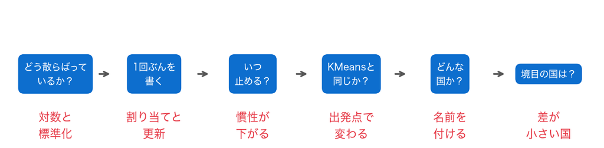

- 6つの小さな問いに答えて、142か国を3つに分けた

## 今日の歩み

⑥ 振り返る●●○○○○

物差し → 1回ぶん → `while`で止まるまで → `KMeans`と答え合わせ → 名前 → 境目の国

## 今日持ち帰る1文

⑥ 振り返る●●●○○○

k-meansは「いちばん近い中心に割り当てる → 中心を重心に動かす」を、中心が動かなくなるまでくり返す。慣性は回るたびに下がるので必ず止まるが、止まった先は出発点で変わる。

## 今日の要点①：分け方

⑥ 振り返る●●●●○○

- 距離で分けるので、数の大きさが違う列は標準化してから。右に裾を引く列は対数に
- 慣性（中心までの距離の二乗和）は、割り当てでも更新でも増えない
- `KMeans`は、出発点を`n_init`通り試し、慣性のいちばん小さい答えを残す

## 今日の要点②：読み方

⑥ 振り返る●●●●●○

- グループの番号に意味はない。要約して名前を付ける
- 大陸は使っていないが、グループは大陸とかなり重なる
- 境目の国は、中心までの距離の差で見つけ、1か国ずつ確かめる

## 今日の要点③：Python

⑥ 振り返る●●●●●●

- `while 条件:`は、条件が`True`のあいだくり返す。止まる条件を中で書き換える
- 回数の上限も付けておく（`while moved and n < 100:`）
- 2回目に同じことをしたくなったら、`def`でまとめる

## 課題の出し方

⑦ このあと●○○○

- ノートの最後の「課題（提出）」に取り組む
- 応用②の答えと応用③の文章を、LACSに入力して提出（＝出席。期限なし）
- AIを使ってもよい。何を聞いて、どう直したかを1行書く

## 次回予告：論文のコード

⑦ このあと●●○○

- 今日は、`KMeans`の中で何がくり返されているかを確かめた
- 中身を知っている道具なら、ほかの人のコードに出てきても読める

## 次回の問い

⑦ このあと●●●○

研究者が論文のために書いて公開したコードを、どこから、どう読めばよいか？

## このあと：課題へ

⑦ このあと●●●●

ノートの「課題（提出）」へ。2007年のグループの物差しで、1997年の国々を割り当て直します。

# ここから先は解答

## 課題のあとで見る

課題（提出）に取り組んでから見てください。動画の人は、ここで一時停止。

## 応用①：1997年に当てはめる

```python
d97 = gm[gm['year'] == 1997].reset_index(drop=True)
d97 = d97.rename(columns={'lifeExp': '平均寿命'})
d97['対数GDP'] = np.log10(d97['gdpPercap'])
X97 = sc.transform(d97[['平均寿命', '対数GDP']])
d['1997年'] = pd.Series(km.predict(X97)).map(name)
print(pd.crosstab(d['1997年'], d['名前']))
print((d['名前'] != d['1997年']).sum())
```

```
名前       中位  低寿命・低所得  長寿・高所得
1997年
中位       48        1       5
低寿命・低所得   3       51       0
長寿・高所得    0        0      34
9
```

## 物差しは2007年のまま

- `sc.transform`：2007年の平均と標準偏差で標準化する（`fit`しない）
- `km.predict`：いちばん近い中心に割り当てる。2節の「割り当て」の1段だけ
- グループが変わった国は9か国

## 応用②：下へ移った国

```python
rank = {'低寿命・低所得': 0, '中位': 1, '長寿・高所得': 2}
down = d['名前'].map(rank) < d['1997年'].map(rank)
print(d.loc[down, ['国', '1997年', '名前', '平均寿命']])
print(d97.loc[down, ['country', '平均寿命']])
print('答え:', d.loc[down, '国'].values[0])
```

```
                国 1997年       名前    平均寿命
117  South Africa    中位  低寿命・低所得  49.339
          country    平均寿命
117  South Africa  60.236
答え: South Africa
```

## 10年の動き

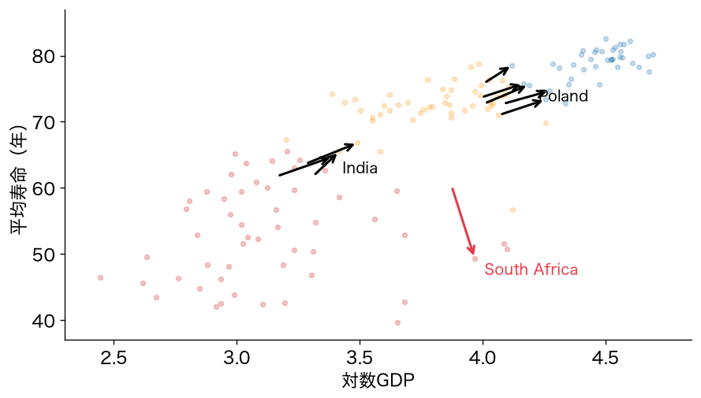

- 黒は上のグループへ、赤は下のグループへ移った国

## 南アフリカだけが下へ

- 上へ移ったのは、インドやポーランドなど8か国
- 下へ移ったのは南アフリカだけ。平均寿命が60.2年から49.3年に下がった
- GDPではなく、寿命の低下で下のグループに移った

## 応用③：模範例

2007年の142か国を、平均寿命と1人あたりGDPから、低寿命・低所得（52か国）、中位（51か国）、長寿・高所得（39か国）の3つに分けました。同じ物差しで1997年に当てはめると、10年でグループが変わった国は9か国で、インドやポーランドなど8か国は上のグループへ移り、下へ移ったのは南アフリカだけでした。南アフリカは平均寿命が60.2年から49.3年に下がっており、所得より保健の支援を優先すべき国です。ボツワナや赤道ギニアのように所得の割に寿命の短い国や、トリニダード・トバゴのように境目にいる国は、グループの方針をそのまま当てはめず、1か国ずつ確かめます。

## 書き方の型

- 1文目：グループの分け方と、それぞれの国の数
- 2文目：移り変わり（数と、目立つ国）
- 3文目：方針をそのまま当てはめにくい国

# 発展（任意）

## k-meansで、人が決めたこと

- グループの数$K$を、先に決めた
- すべての国を、どこかのグループに必ず入れた
- 境目の国も、まばらな場所の国も、どこかに入れられる

## HDBSCAN

- 点が密に集まっている場所をグループとし、まばらな場所の点は外れ値（ラベル −1）にする
- HDBSCAN（エイチ・ディー・ビー・スキャン）と呼ぶ
- $K$は決めない。決めるのは、グループと認める最小の国の数（`min_cluster_size`）

## お手本：HDBSCANで分ける

```python
from sklearn.cluster import HDBSCAN
hdb = HDBSCAN(min_cluster_size=8, copy=True).fit_predict(X)
d['HDB'] = hdb
print('グループの数:', hdb.max() + 1)
print('外れ値:', (hdb == -1).sum(), 'か国')
d.groupby('HDB').agg(国数=('国', 'size'),
                     平均寿命=('平均寿命', 'mean'),
                     GDP中央値=('GDP', 'median')).round(1)
```

## 3つのグループと41か国の外れ値

```
グループの数: 3
外れ値: 41 か国
     国数  平均寿命   GDP中央値
HDB
-1   41  58.3   3548.3
 0   30  57.5   1209.3
 1   39  73.2   7458.4
 2   32  79.6  33205.2
```

## 図で見る

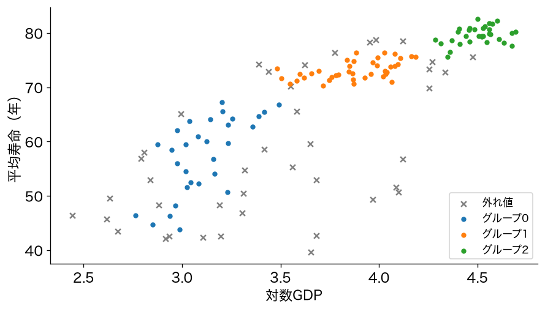

- ×が外れ値。3つのグループは、k-meansの3つのグループの芯にあたる

## 外れ値になった国

```python
out = d[d['HDB'] == -1]
print(out['名前'].value_counts())
out.sort_values('平均寿命')[['国', '名前', '平均寿命', 'GDP']].head(5)
```

```
名前
低寿命・低所得    26
中位         10
長寿・高所得      5
                国       名前  平均寿命     GDP
121     Swaziland  低寿命・低所得  39.6  4513.5
86     Mozambique  低寿命・低所得  42.1   823.7
140        Zambia  低寿命・低所得  42.4  1271.2
112  Sierra Leone  低寿命・低所得  42.6   862.5
73        Lesotho  低寿命・低所得  42.6  1569.3
```

## 2種類の外れ値

- まばらな場所の国：平均寿命のとても短い国々は、たがいに離れて散らばる
- グループのあいだの国：境目にいる国
- どこにも無理に入れないので、1か国ずつ確かめるべき国が見えてくる

## 試すなら

- `min_cluster_size`を5や15に変えて、グループの数と外れ値の数を見る
- $K$を決めない代わりに、何を「密」とみなすかを決めている

## おわり

- 今日は、k-meansを`while`で書き、142か国を3つのグループに分けた
- 慣性が下がり続けて止まること、止まる先は出発点で変わることを確かめた